# homework2019-10-10

Khó͘ GēChoân

10/9/2019

# 8.20

### sample space:*正正正、正正反、正反正、反正正、反反反、反反正、反正反、正反反*

```r
space=c(1/8,3/8,3/8,1/8)
data82a=data.frame( "反面的次數X"=c( 0 , 1,3,4),"機率x"=space)
data82a$`反面的次數X`=paste(data82a$`反面的次數X`, "次")
data82b=data.frame("正反面的差距Y"=c(-3,-1,1,3),"機率y"=c(1/8,3/8,3/8,1/8))

data82b$`正反面的差距Y`=paste(data82b$`正反面的差距Y`, "次")
data82c=data.frame("正反面的總和Z"=c(3), "機率z"=1)

# a.
data82a
```

```
##   反面的次數X 機率x
## 1        0 次 0.125
## 2        1 次 0.375
## 3        3 次 0.375
## 4        4 次 0.125
```

```r
# b.
data82b
```

```
##   正反面的差距Y 機率y
## 1         -3 次 0.125
## 2         -1 次 0.375
## 3          1 次 0.375
## 4          3 次 0.125
```

```r
# c.
data82c
```

```
##   正反面的總和Z 機率z
## 1             3     1
```

# 8.40

1. expected value=16 minutes
2. 不會。期望值是長時間下來的平均，而16分鐘並不是可能會出現的等待時間

```r
0.2*20+0.8*15
```

```
## [1] 16
```

# 8.52

## a.

1. 總共進行10次，所以次數是固定的
2. 因為每次的照片都是新的，所以是獨立事件
3. 結果可能是猜對或猜錯，所以是有兩個可能結果沒錯
4. 每一次猜對的機率也都相同，都是四分之一

## b.

1.是。n是10, p是1/4。

## c.

P(X>=6)=0.01972771

## d.

P(X>=6)=0.3769531

## e.

可以發現如果是任意四選一的話，答對六題以上的機率很低，大約只有2%。所以如果答題者猜對六題以上的話，很有可能是他並不只是任意的四選一，而有其他能力幫助判斷。

```r
# c.
AnsC=1-pbinom(5,size=10, prob=.25)
AnsC
```

```
## [1] 0.01972771
```

```r
# d.
AnsD=1-pbinom(5, size=10, prob=.5)
AnsD
```

```
## [1] 0.3769531
```

# 8.74

## a. 選到人花低於450塊的機率是0.7733726

## b. *0.8413447*

## c. *0.6147174*

```r
pnorm(450, mean=360, sd = 120)
```

```
## [1] 0.7733726
```

```r
1-pnorm(240, mean = 360, sd = 120)
```

```
## [1] 0.8413447
```

```r
pnorm(450, mean = 360, sd = 120)-pnorm(240, mean = 360, sd = 120)
```

```
## [1] 0.6147174
```

# 8.86

## a.

X是受試者在一百次試驗裡面，成功猜到正確答案次數，每一次猜都隨機的可能是正確或錯誤。n是100，p是四分之一（從四張卡裡面隨機選一張）。

## b.

平均是25，標準差是4.330127。

## c.

*0.02759456*

## d.

*0.00000006638502*

機率低到只有千萬分之一不到，代表受試者應該不是任意的猜。

```r
m1=100*0.25
sd1=sqrt(m1*(1-0.25))
1-pbinom(33, size=100, prob=.25)
```

```
## [1] 0.02759456
```

```r
Ans886d=1-pbinom(49, size=100, prob=.25 )
format(Ans886d, scientific = F)
```

```
## [1] "0.00000006638502"
```

## 8.96

1. 平均：Charles=45, Julia=40, Alex=40 標準差：Charles=2.12132, Julia=2.828427, Alex=2.828427
2. 團隊平均：125 團隊標準差：4.527693

c.如果三個人的答對機率一樣，團隊分數才會是二項分配。

4. *0.09255601*

```r
#a
mCharles=50*.9
mJulia=50*.8
mAlex=50*.8

sdCharles=sqrt(mCharles*(1-.9))
sdJulia=sqrt(mJulia*(1-.8))
sdAlex=sqrt(mAlex*(1-.8))

#b
mTeam=mCharles+mJulia+mAlex
sdTeam=sqrt(mCharles*(1-.9)+mJulia*(1-.8)+mAlex*(1-.8))

#c

#d

1-pnorm(131, mean=mTeam,sd=sdTeam )
```

```
## [1] 0.09255601
```

# R程式練習題

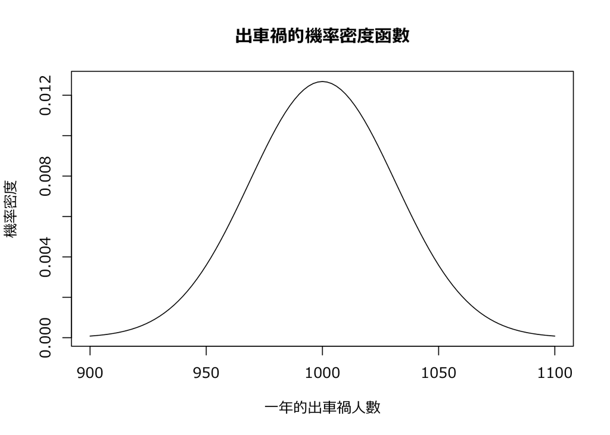

```r
mCar=100000*.01
sdCar=sqrt(mCar*(1-.01))
curve(dnorm(x, mean=mCar, sd=sdCar),900, 1100, main="出車禍的機率密度函數", xlab="一年的出車禍人數", ylab="機率密度", family="Meiryo" )
```

```r
pCar=1-pnorm(960, mean=mCar, sd=sdCar)#每一年超過960次車禍的機率
pCar
```

```
## [1] 0.8981861
```

```r
pbinom(0, size=4, prob=pCar) #任期內超過960次車禍的機率，因為美年的結果可能發生或不發生，且是獨立事件、固定次數，因此可用二項式分配來計算四年都不發生的機率。
```

```
## [1] 0.0001074555
```

```r
rm(list=ls())
Y100=rbinom(100, 100000, .01)
max(Y100)
```

```
## [1] 1083
```